# DYNECOM EDA synchrony

Ben Cowley

10 March 2019

# PARAMETERS

```r
# data-type parameters
basepath <- 'EDAcsv'
feature <- 'scr'
centr <- TRUE
skale <- TRUE
# List of conditions
paircond <- c('a', 'b')
dyadcond <- c('D', 'S')
physcond <- c('both', 'eeg', 'resp', 'na')
timecond <- c('BL', '30s', '6min')
# sliding window parameters
wndw <- 40
step <- wndw / 2 # 50% overlap steps
method <- "sd" # options are: max, mean, median, min, prod, sd, sum, var; see ?RcppRoll
REPS <- 10000
```

# CODE WRANGLING

Here, as an example, we select condition *D, both, 6min* We collect *a* and *b* versions of the data (which are then bound together for convenience)

```r
# Create the first dataset as an example
cond_str <- paste0('_', dyadcond[1], '_', physcond[1], '.*', timecond[3])
dfa <- read_all_recordings(basepath, pat=paste0(paircond[1], cond_str), ext="csv", skip = 1)
dfb <- read_all_recordings(basepath, pat=paste0(paircond[2], cond_str), ext="csv", skip = 1)
dfa$ab <- 1
dfb$ab <- 2
df <- rbind(dfa, dfb)

subjs <- unique(df$Part)
sbjix <- seq(1, length(subjs))
```

# SLIDING WINDOW CORRELATIONS

The diagonal of the matrix (true dyad correlations) provides the test measurement. The diagonal is averaged (correlation aggregation is not needed because the number of elements per correlation is constant across dyads).

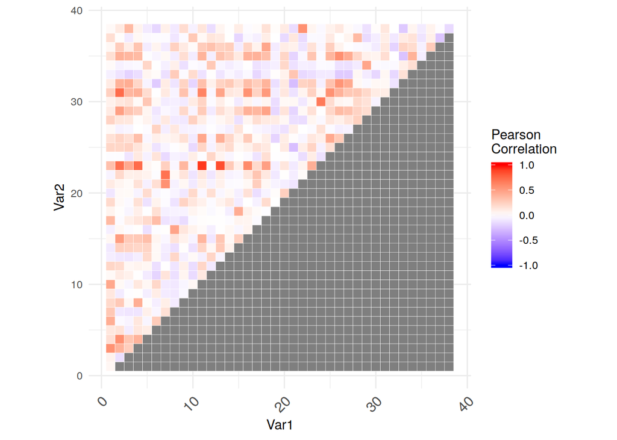

```r
Db6m.pr1.1 <- corr_rollme_1pr(df, 1, 1, feature, wndw, step, CTR = centr, SCL = skale)
# Db6m.corr <- corr_rollme_allpr(df, feature, wndw, step)

Db6m.cormat <- corr_rollme_mat(df, feature, wndw, step, method, CTR = centr, SCL = skale)
Db6m.corr <- diag(Db6m.cormat$corr)
# Db6m.count <- Db6m.cormat$count

# Aggregates
Db6m.avg.cor <- mean(Db6m.corr)   # for constant N, Hunter-Schmidt aggregation is equivalent to average correlation
Db6m.abav.cor <- mean(abs(Db6m.corr)) # for constant N, Hunter-Schmidt aggregation is equivalent to average correlation

# show corr matrix
plot_rwb_cormat(Db6m.cormat$corr)
```

# MATRIX SAMPLING

To obtain a random sample (without replacement) of the pair-wise correlations, we simply shuffle the columns of the correlation matrix, displayed.

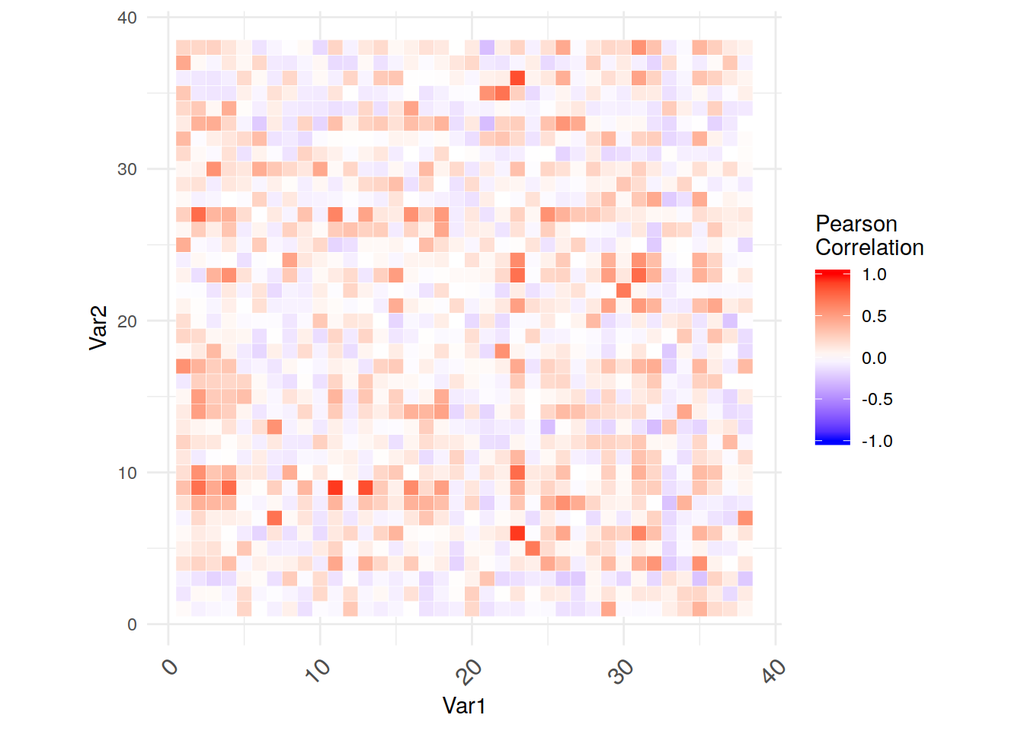

```r
samp <- sample_matrix(Db6m.cormat$corr, repl = FALSE)
plot_rwb_cormat(samp$sampmat)
```

# PERMUTATION TESTING

To obtain a permutation test statistic, we repeat the random sampling 10000 times, generating a distribution of correlations. We plot the observed real correlation against the distribution to see the statistical difference of the obervation from a random distribution. P values are obtained by counting how many permuted mean-differences are larger than the one we observed in our actual data. We can then divide this by the number of items in our permutation distribution.

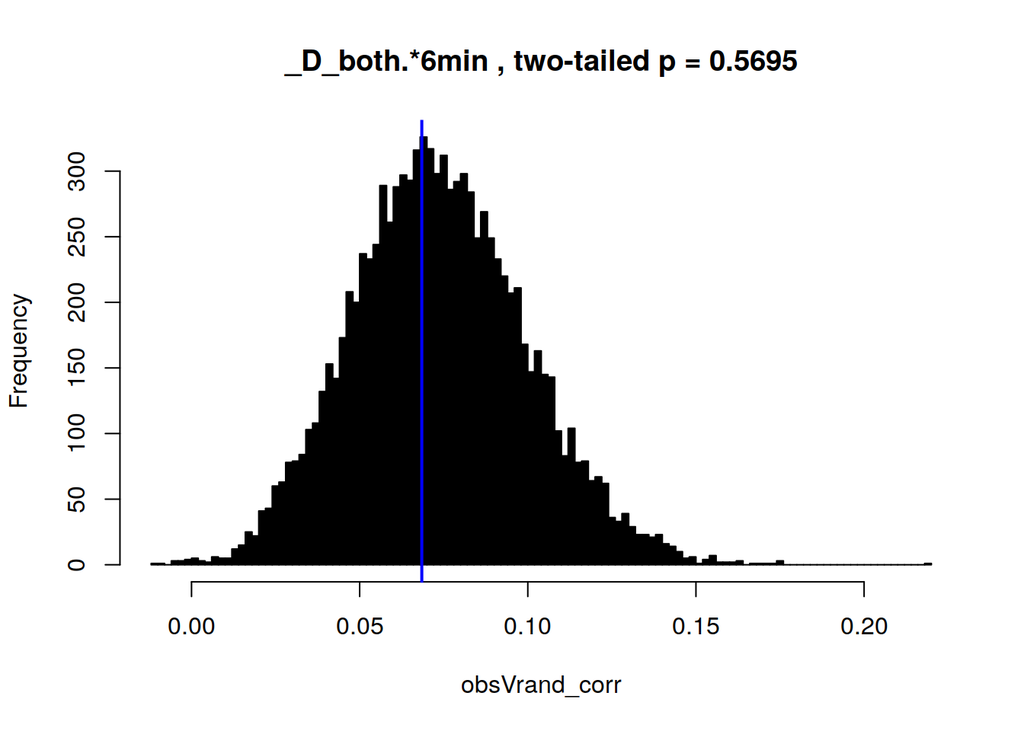

```r
# CONDITION D_both_6mins
obsVrand_corr <- replicate(REPS, sampmat_diag_stat(mean, Db6m.cormat$corr))
hist(obsVrand_corr, col='black', breaks=100,
     main = paste(cond_str, ", two-tailed p =", sum(abs(obsVrand_corr) > abs(Db6m.avg.cor)) / REPS))
abline(v=Db6m.avg.cor, col='blue', lwd=2)
```

## OTHER DYADIC CONDITIONS

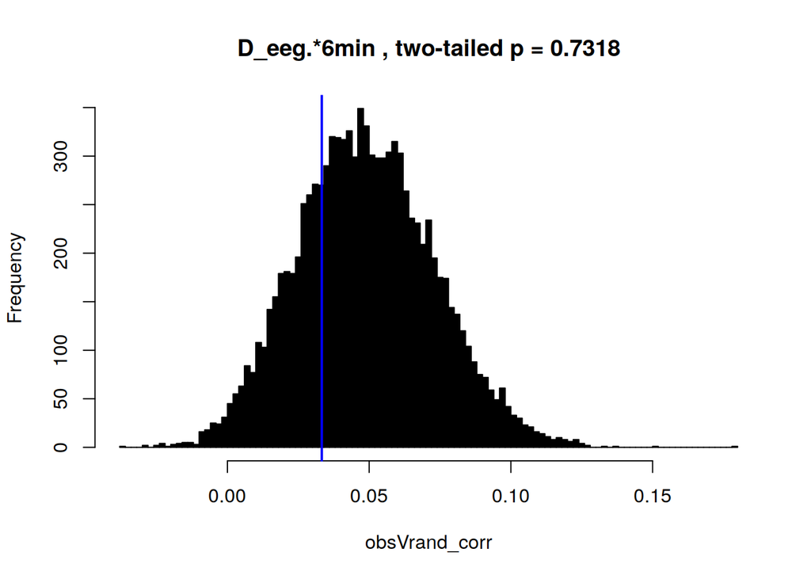

```r
# CONDITION D_eeg_6mins
cond_str <- paste0(dyadcond[1], '_', physcond[2], '.*', timecond[3])
patts <- c(paste0(paircond[1], '_', cond_str), paste0(paircond[2], '_', cond_str))
De6m.cor <- cond2rollcormat(basepath, patts, feature, wndw, step, method, triangle = FALSE, CTR = centr, SCL = skale)
# Permutation testing
obsVrand_corr <- replicate(REPS, sampmat_diag_stat(mean, De6m.cor$cormat))
hist(obsVrand_corr, col='black', breaks=100,
     main = paste(cond_str, ", two-tailed p =", sum(abs(obsVrand_corr) > abs(De6m.cor$avg.cor)) / REPS))
abline(v=De6m.cor$avg.cor, col='blue', lwd=2)
```

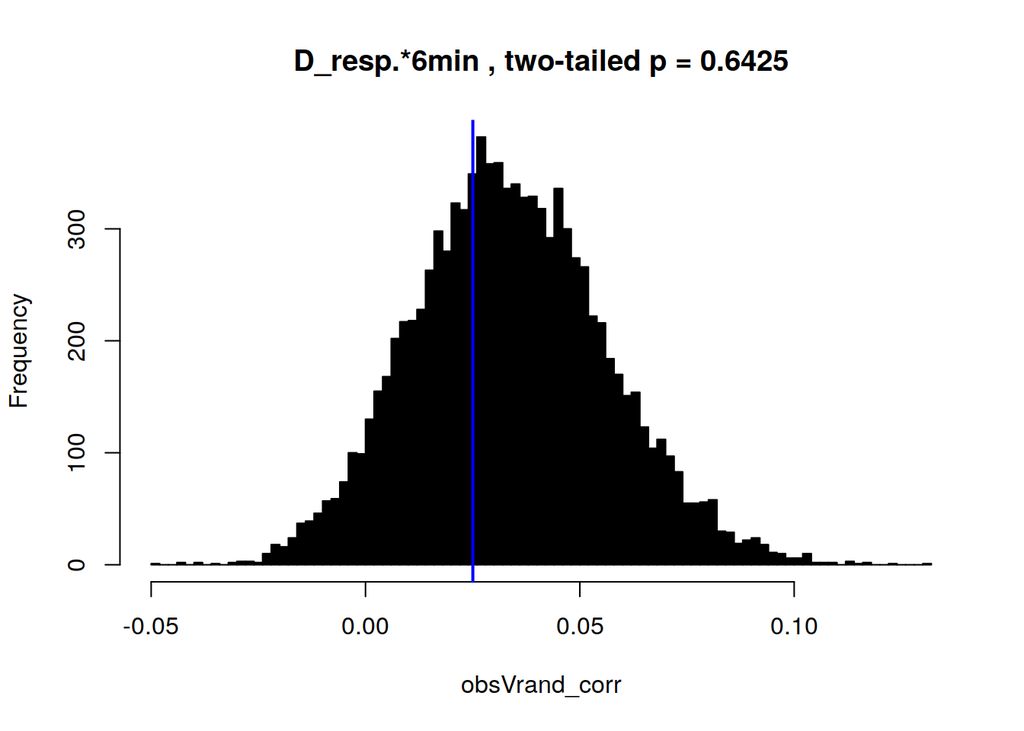

```r
# CONDITION D_resp_6mins
cond_str <- paste0(dyadcond[1], '_', physcond[3], '.*', timecond[3])
patts <- c(paste0(paircond[1], '_', cond_str), paste0(paircond[2], '_', cond_str))
Dr6m.cor <- cond2rollcormat(basepath, patts, feature, wndw, step, method, triangle = FALSE, CTR = centr, SCL = skale)
# Permutation testing
obsVrand_corr <- replicate(REPS, sampmat_diag_stat(mean, Dr6m.cor$cormat))
hist(obsVrand_corr, col='black', breaks=100,
     main = paste(cond_str, ", two-tailed p =", sum(abs(obsVrand_corr) > abs(Dr6m.cor$avg.cor)) / REPS))
abline(v=Dr6m.cor$avg.cor, col='blue', lwd=2)
```

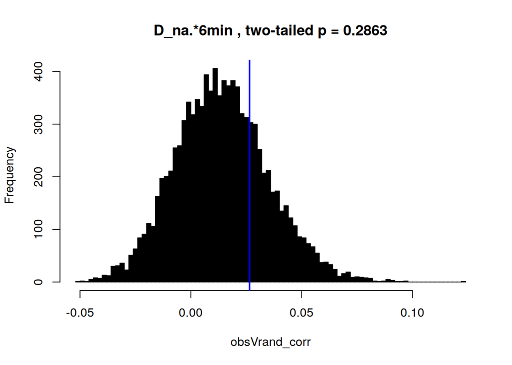

```r
# CONDITION D_na_6mins
cond_str <- paste0(dyadcond[1], '_', physcond[4], '.*', timecond[3])
patts <- c(paste0(paircond[1], '_', cond_str), paste0(paircond[2], '_', cond_str))
Dn6m.cor <- cond2rollcormat(basepath, patts, feature, wndw, step, method, triangle = FALSE, CTR = centr, SCL = skale)
# Permutation testing
obsVrand_corr <- replicate(REPS, sampmat_diag_stat(mean, Dn6m.cor$cormat))
hist(obsVrand_corr, col='black', breaks=100,
     main = paste(cond_str, ", two-tailed p =", sum(abs(obsVrand_corr) > abs(Dn6m.cor$avg.cor)) / REPS))
abline(v=Dn6m.cor$avg.cor, col='blue', lwd=2)
```

## ALL SOLO CONDITIONS

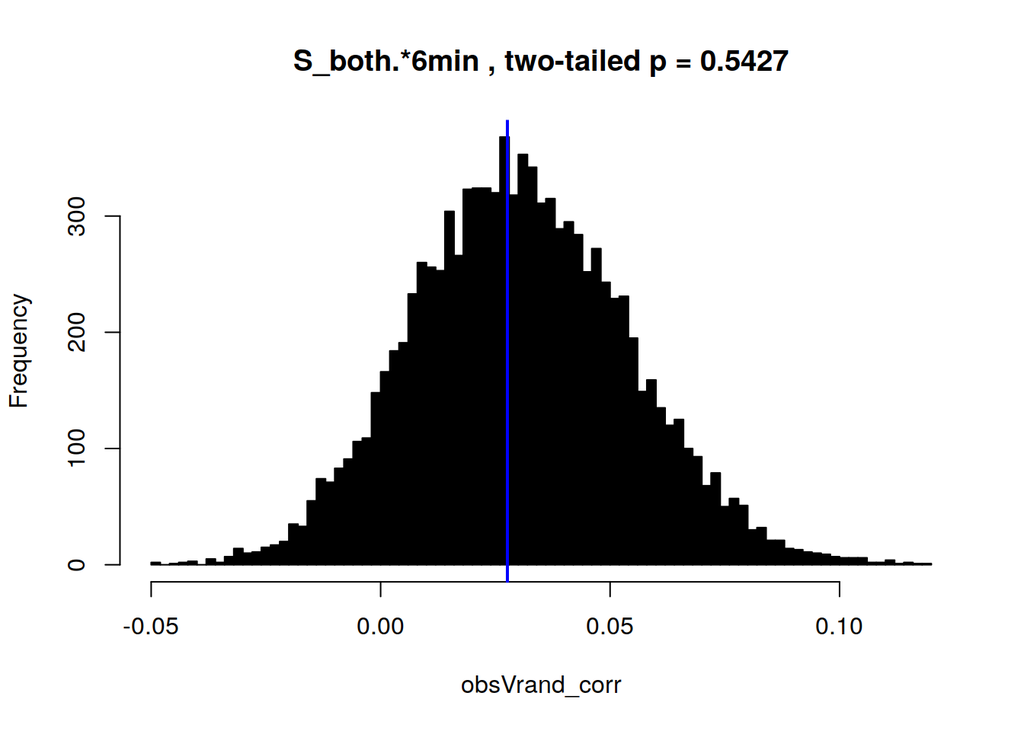

```r
# CONDITION S_both_6mins
cond_str <- paste0(dyadcond[2], '_', physcond[1], '.*', timecond[3])
patts <- c(paste0(paircond[1], '_', cond_str), paste0(paircond[2], '_', cond_str))
Sb6m.cor <- cond2rollcormat(basepath, patts, feature, wndw, step, method, triangle = FALSE, CTR = centr, SCL = skale)
# Permutation testing
obsVrand_corr <- replicate(REPS, sampmat_diag_stat(mean, Sb6m.cor$cormat))
hist(obsVrand_corr, col='black', breaks=100,
     main = paste(cond_str, ", two-tailed p =", sum(abs(obsVrand_corr) > abs(Sb6m.cor$avg.cor)) / REPS))
abline(v=Sb6m.cor$avg.cor, col='blue', lwd=2)
```

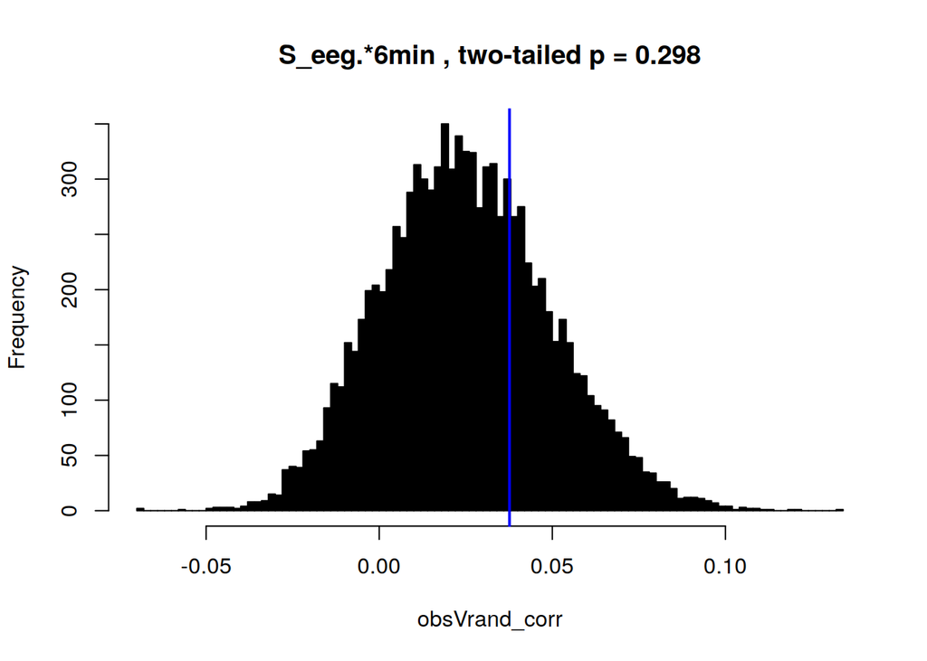

```r
# CONDITION S_eeg_6mins
cond_str <- paste0(dyadcond[2], '_', physcond[2], '.*', timecond[3])
patts <- c(paste0(paircond[1], '_', cond_str), paste0(paircond[2], '_', cond_str))
Se6m.cor <- cond2rollcormat(basepath, patts, feature, wndw, step, method, triangle = FALSE, CTR = centr, SCL = skale)
# Permutation testing
obsVrand_corr <- replicate(REPS, sampmat_diag_stat(mean, Se6m.cor$cormat))
hist(obsVrand_corr, col='black', breaks=100,
     main = paste(cond_str, ", two-tailed p =", sum(abs(obsVrand_corr) > abs(Se6m.cor$avg.cor)) / REPS))
abline(v=Se6m.cor$avg.cor, col='blue', lwd=2)
```

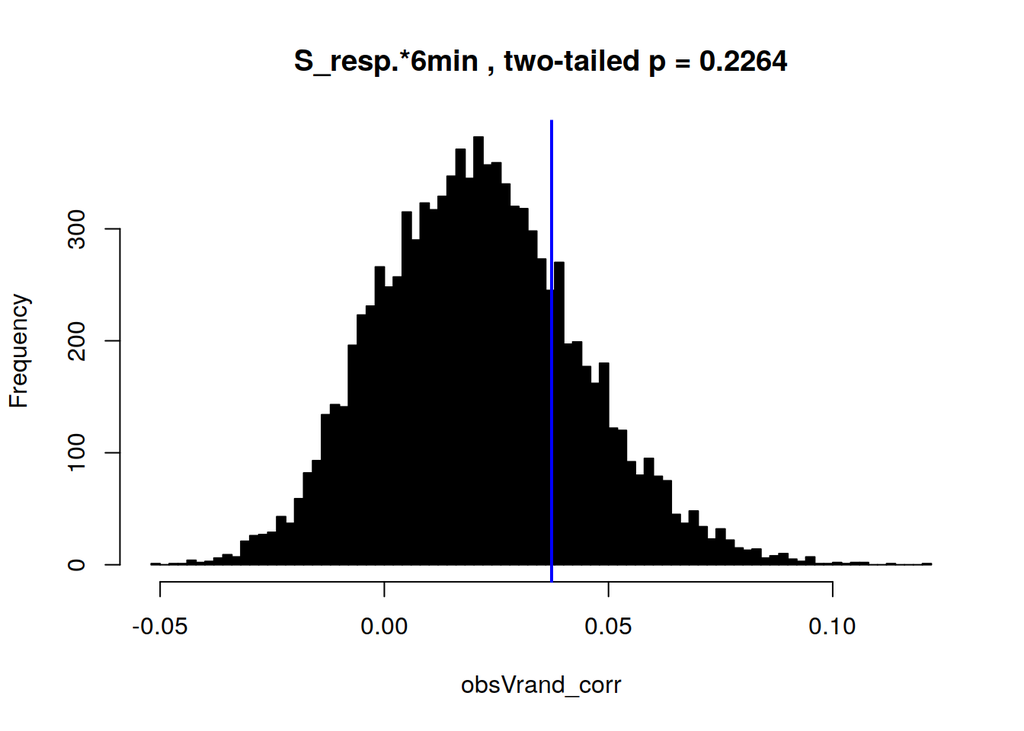

```r
# CONDITION S_resp_6mins
cond_str <- paste0(dyadcond[2], '_', physcond[3], '.*', timecond[3])
patts <- c(paste0(paircond[1], '_', cond_str), paste0(paircond[2], '_', cond_str))
Sr6m.cor <- cond2rollcormat(basepath, patts, feature, wndw, step, method, triangle = FALSE, CTR = centr, SCL = skale)
# Permutation testing
obsVrand_corr <- replicate(REPS, sampmat_diag_stat(mean, Sr6m.cor$cormat))
hist(obsVrand_corr, col='black', breaks=100,
     main = paste(cond_str, ", two-tailed p =", sum(abs(obsVrand_corr) > abs(Sr6m.cor$avg.cor)) / REPS))
abline(v=Sr6m.cor$avg.cor, col='blue', lwd=2)
```

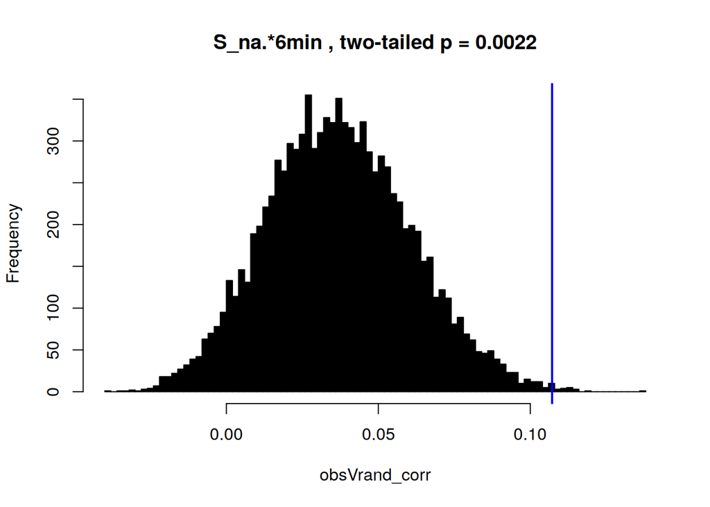

```r
# CONDITION S_na_6mins
cond_str <- paste0(dyadcond[2], '_', physcond[4], '.*', timecond[3])
patts <- c(paste0(paircond[1], '_', cond_str), paste0(paircond[2], '_', cond_str))
Sn6m.cor <- cond2rollcormat(basepath, patts, feature, wndw, step, method, triangle = FALSE, CTR = centr, SCL = skale)
# Permutation testing
obsVrand_corr <- replicate(REPS, sampmat_diag_stat(mean, Sn6m.cor$cormat))
hist(obsVrand_corr, col='black', breaks=100,
     main = paste(cond_str, ", two-tailed p =", sum(abs(obsVrand_corr) > abs(Sn6m.cor$avg.cor)) / REPS))
abline(v=Sn6m.cor$avg.cor, col='blue', lwd=2)
```

## RELATION TO SELF-REPORTS

Read Simo’s csv file and create linear regression on S.na synchrony data

```r
df <- read.csv('dynecom_Data.csv')
srep.sbjix <- sort(unique(df$PairID))

# DEALING WITH THE EDA RESULT CONDITION FIRST
df.Sna.a <- df %>% filter(Scenario == 5 & AorB == 1)
df.Sna.a$sync <- Sn6m.cor$corrs
df.Sna.b <- df %>% filter(Scenario == 5 & AorB == 2)
df.Sna.b$sync <- Sn6m.cor$corrs
df.Sna <- rbind(df.Sna.a, df.Sna.b)

df.Sna.mdl <- lm(sync ~ Batson_empathy + inter_arousal + inter_dominance + inter_valence + interCP + interPAI + interPAU + Relationship_legth_mean + Closeness_mean + Sex, data = df.Sna)
summary(df.Sna.mdl)
```

```
##
## Call:
## lm(formula = sync ~ Batson_empathy + inter_arousal + inter_dominance +
##     inter_valence + interCP + interPAI + interPAU + Relationship_legth_mean +
##     Closeness_mean + Sex, data = df.Sna)
##
## Residuals:
##      Min       1Q   Median       3Q      Max
## -0.45192 -0.10228 -0.02965  0.09196  0.52808
##
## Coefficients:
##                          Estimate Std. Error t value Pr(>|t|)
## (Intercept)              0.237732   0.516266   0.460  0.64666
## Batson_empathy           0.012641   0.018926   0.668  0.50651
## inter_arousal            0.014191   0.024668   0.575  0.56702
## inter_dominance         -0.019335   0.022331  -0.866  0.38968
## inter_valence            0.025134   0.029849   0.842  0.40275
## interCP                  0.005507   0.036734   0.150  0.88129
## interPAI                -0.067412   0.055991  -1.204  0.23283
## interPAU                 0.003834   0.038689   0.099  0.92137
## Relationship_legth_mean  0.017211   0.004077   4.222 7.47e-05 ***
## Closeness_mean          -0.041961   0.017026  -2.464  0.01629 *
## Sex                      0.138256   0.045550   3.035  0.00342 **
## ---
## Signif. codes:  0 '***' 0.001 '**' 0.01 '*' 0.05 '.' 0.1 ' ' 1
##
## Residual standard error: 0.1903 on 67 degrees of freedom
## Multiple R-squared:  0.3767, Adjusted R-squared:  0.2837
## F-statistic:  4.05 on 10 and 67 DF,  p-value: 0.0002272
```

## DIFFERENCE OF CONDITIONS

Check the statistical significance of difference in synchrony between conditions. We do this by subtracting correlation vector of one condition from the other condition, then performing one-sample t-test and permutation test of difference from zero. We take the subtraction in the direction of our hypothesis of which is greater: for example, we expect synchrony to be higher in Dyad than Solo condition, so we test (Dyad - Solo).

```r
# idx <- intersect(subjs, )
DSboth <- Db6m.corr - Sb6m.cor$corrs
t.test(DSboth)
```

```
##
##  One Sample t-test
##
## data:  DSboth
## t = 1.0645, df = 37, p-value = 0.294
## alternative hypothesis: true mean is not equal to 0
## 95 percent confidence interval:
##  -0.03691177  0.11862181
## sample estimates:
##  mean of x
## 0.04085502
```

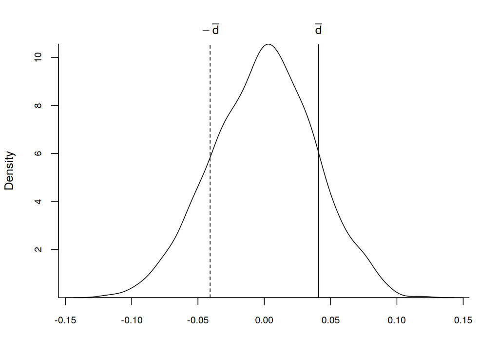

```
## [1] 0.286
```

```r
onet.permutation(DSboth)
```

```r
# DSeeg <- De6m.cor$corrs - Se6m.cor$corrs
# t.test(DSeeg)
# onet.permutation(DSeeg)
#
# DSresp <- Dr6m.cor$corrs - Sr6m.cor$corrs
# t.test(DSresp)
# onet.permutation(DSresp)

DSnone <- Dn6m.cor$corrs - Sn6m.cor$corrs
t.test(DSnone)
```

```
##
##  One Sample t-test
##
## data:  DSnone
## t = -1.6454, df = 38, p-value = 0.1081
## alternative hypothesis: true mean is not equal to 0
## 95 percent confidence interval:
##  -0.17995267  0.01858201
## sample estimates:
##   mean of x
## -0.08068533
```

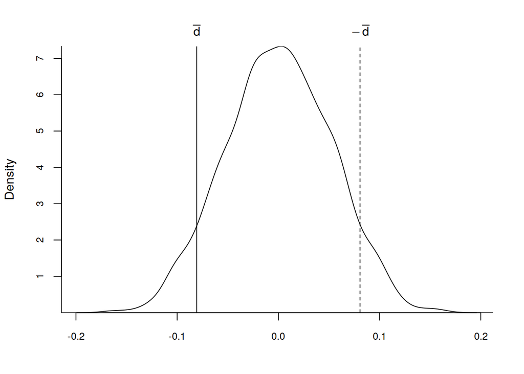

```
## [1] 0.124
```

```r
onet.permutation(DSnone)
```